## **Linear Regression**

### Gustavo Hideo H. Correa

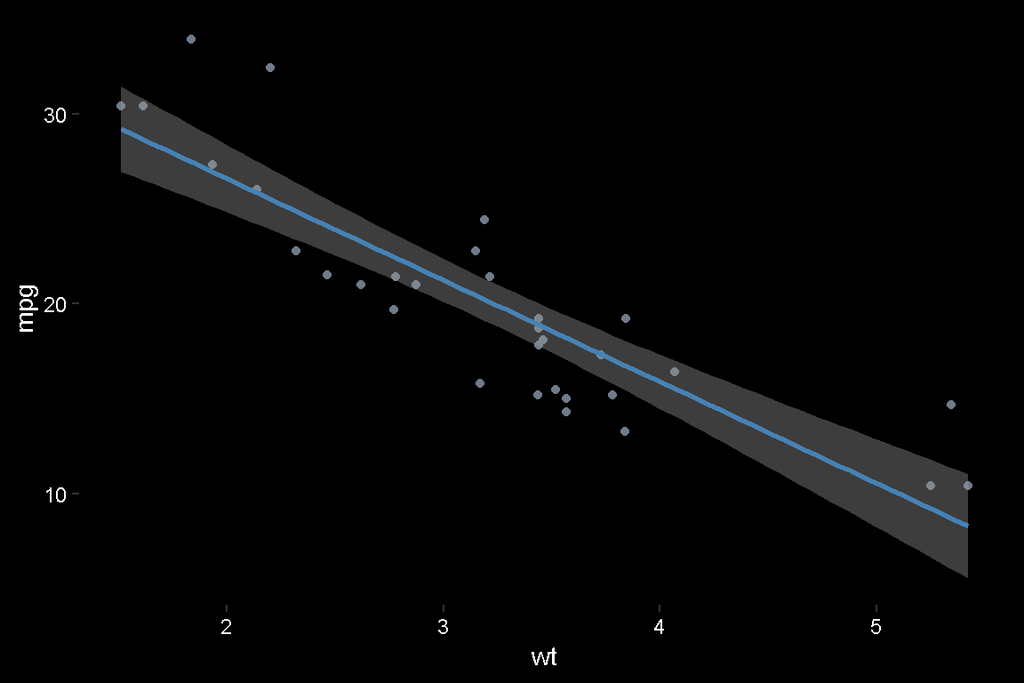

```r
mtcars %>%
  ggplot(aes(wt, mpg)) +
  geom_point(aes(),color = "lightsteelblue4") +
  geom_smooth(method = "lm", se = T, color = "steelblue") +
  myTheme
```

# **Linear Regression | Interpretation**

## **Linear Regression | Interpretation**

$$Y_i = \overbrace{\underbrace{\beta_0}_\text{intercept} + \underbrace{\beta_1}_\text{slope} X_i + \epsilon_i} ^ \text{true regression relation}
\quad \text{where} \ \epsilon_i \sim N(0, \sigma^2)$$

**Intercept**

The average `Y` value when `X` is `0`.

**Slope**

The change in the average `Y` value for each unit increase in `X`

**Error**

The difference form the data point and the **true line** (unknown line)

**Sigma** Standard deviation of the error

## Model Parameters

**Slope**

```r
b_1 <- sum( X*(Y - mean(Y)) ) / sum( (X - mean(X))^2 )
```

**Intercept**

```r
b_0 <- mean(Y) - b_1*mean(X)
```

$\hat{Y}$ is the estimator of $E\{Y\}$.

$$\hat{Y}_i = b_0 + b_1 X_i$$

$$E\{Y\} = \beta_0 + \beta_1 X_i$$

# **Numerical Summaries**

## **Residuals**

Difference from the data point to the **estimate line** (known line)

$$\underbrace{Y_i}_\text{data point} - \underbrace{\hat{Y}_i}_\text{estimated Y (line)}$$

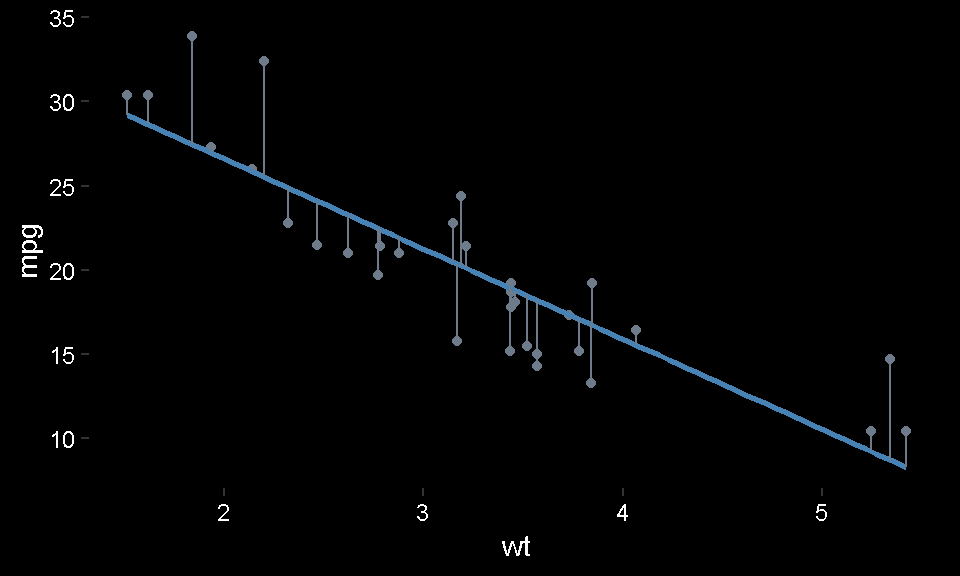

```r
d <- mtcars
fit <- lm(mpg ~ wt, data = d)
d$predicted <- predict(fit)
d$residuals <- residuals(fit)

d %>%
  ggplot(aes(wt, mpg)) +
  geom_point(aes(),color = "lightsteelblue4") +
  geom_smooth(method = "lm", se = F, color = "steelblue") +
  geom_segment(aes(xend = wt, yend = predicted), color = "lightsteelblue4") +
  myTheme
```

**Residual Std. Error** The smaller the best, showing that the data does not deviate much from the average Y (line).

```r
lm1 <- lm(mpg ~ wt, data = mtcars)
sqrt(sum(lm1$residuals ^ 2) / 30)
```

```
## [1] 3.045882
```

## Sum fo squares

**Sum of Squared Errors (SSE)**  
Measures how much the residuals deviate from the line

**Sum of Squares Regression (SSR)**  
Measures how much the regression line deviates from the aveage y-value

**Total Sum of Squares (SSTO)**  
Measures how much the y-values deviate from the average y-value  
$ SSTO = SSE + SSR$

**Multiple R-squared (R^2)**  
It’s the proportion of variation in `Y` explained by the regression model $ SSR / SSTO $

`cars`

```r
lm.cars.1 <- lm(dist ~ speed, data = cars)
```

**SSE**

```r
sse <- sum((cars$dist - lm.cars.1$fit)^2)
sse
```

```
## [1] 11353.52
```

**SSR**

```r
ssr <- sum((lm.cars.1$fit - mean(cars$dist))^2)
ssr
```

```
## [1] 21185.46
```

**SSTP**

```r
ssto <- sum((cars$dist - mean(cars$dist))^2)
ssto
```

```
## [1] 32538.98
```

**Multiple R-squared (R^2)**

```r
R2 <- ssr / ssto
# or
R2.b <- 1 - (sse / ssto)

R2
```

```
## [1] 0.6510794
```

**Correlation (r)**

```r
r <- sqrt(R2)
r
```

```
## [1] 0.8068949
```

## Variance

```r
x = c(5, 15, 2, 29, 35, 24, 25, 39)

var(x)
```

```
## [1] 179.6429
```

```r
avg <- mean(x)

# Variance:
((x[1] - avg)^2 + (x[2] - avg)^2 + (x[3] - avg)^2 + (x[4] - avg)^2 + (x[5] - avg)^2 + (x[6] - avg)^2 + (x[7] - avg)^2 + (x[8] - avg)^2) / (length(x) - 1)
```

```
## [1] 179.6429
```

# Regression Assumptions

1. The regression relation between `Y` and `X` is linear
2. The error term are normally distributed with $E\{\epsilon_i\} = 0$
3. The variance of the error terms is constant over all `X` values
4. The `X` values can be considered fixed and measured without error
5. The error terms are independent

$$Y_i = \underbrace{\beta_0 + \beta_1 \overbrace{X_i}^\text{#4}}_\text{#1} + \epsilon_i \quad \text{where} \ \overbrace{\epsilon_i \sim}^\text{#5} \underbrace{N\{0}_\text{#2}, \overbrace{\sigma^2}^\text{#3}\}$$

### Residuals versus Fitted-values Plot

Checks assumptions #1 and #3

- **#1 - Linear relation:** no apparent trends in the plot
- **#3 - Constant variance:** the vertical spread of the residuals remains roughly consistent across all fitted values

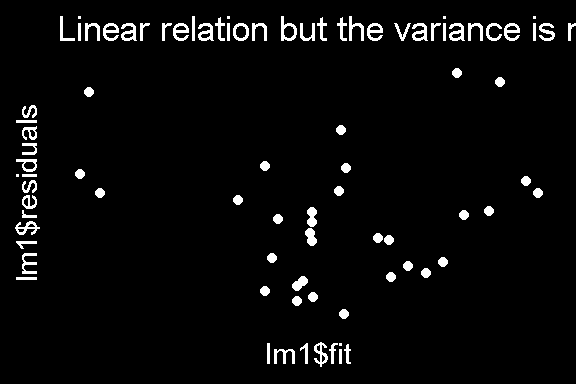

```r
lm1 %>%
  ggplot(aes(lm1$fit, lm1$residuals)) +
  geom_point(color = "white") +
  labs(title = "Linear relation but the variance is not very constant") +
  myTheme +
  theme(axis.text = element_blank(),
        axis.ticks = element_blank())
```

### Q-Q Plot of the Residuals

Checks assumption #2  
* **#2 - Error term is normally distributed:** the QQ-Plot or histogram shows a normal distribution

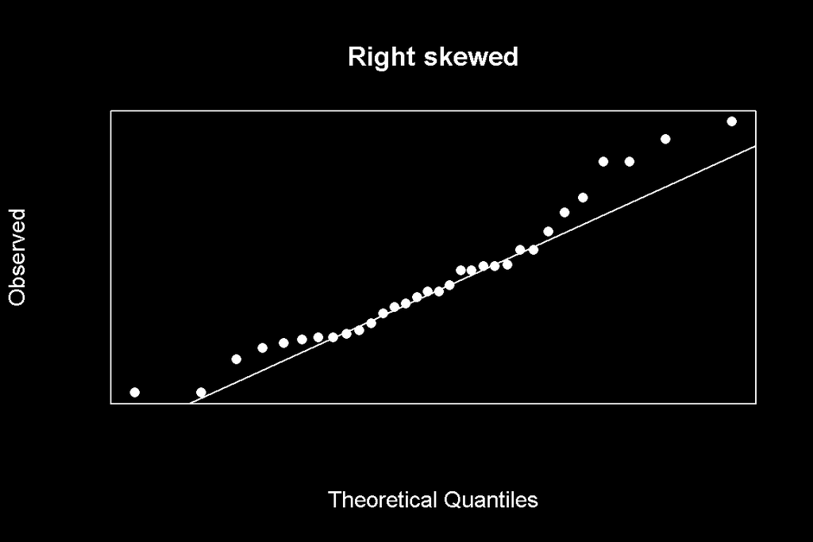

```r
par(bg = "black", col = "white", col.main = "white", col.lab = "white")
qqnorm(mtcars$mpg,
       ylab = "Observed", pch = 16,main = "Right skewed")
qqline(mtcars$mpg)
```

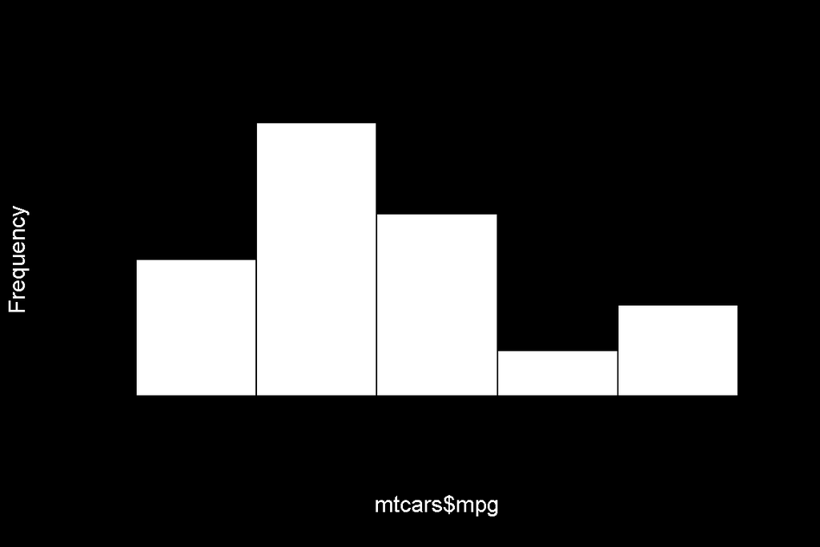

```r
hist(mtcars$mpg, col = "white", main = "")
```

### Residuals versus Order Plot

Checks assumption #5  
* **#5 - Error is independent:** if plotting residuals and the order they were collected shows trends, the model is violated